# Nitrogen concentration in the surface during the summer and winter season in coastal water

NIVA_Nitrovinter

Author

Affiliation

Elianne Egge

Norwegian Institute for Water Research

Published

September 17, 2026

Reviewed by

**TipMetadata**

Table 1: Indicator metadata

[output not shown]

**TipLog**

## 1. Summary

1. **Background and rationale**: Concentration of total nitrogen in the surface layer =< 10m depth during the summer and winter seasons are two of the physical-chemical support parameters for the classification of ecological status in the water masses in Norwegian coastal waters under the Water Framework Directive and the Norwegian Water Regulation. Nitrogen concentration in summer and winter are included as two separate indicators. The summer period better captures the degree of excess influx of nitrogen during the summer season (june-august), when phytoplankton growth consumes a substantial part of the nutrients in the water masses, whereas winter measurements can reveal nutrient concentrations exceeding natural background levels in a water body.
2. **Methods**: The data are classified according to the national guidelines for classification of ecological status under the WFD (DGVF 2026).
3. **Interpretation**: An EQR value close to 1 indicates low effects of inputs and discharges. Values below 0.6 reflect nitrogen concentrations above what is considered good ecological status.
4. **Results and development needs**: The current implementation uses Vannmiljø monitoring data and provides a transparent and reproducible workflow for selecting and calculating the values which are used for determining the nEQR, and determining the nEQR. Future development should focus on broader geographic coverage, automated linkage to national typology datasets and formal uncertainty estimation. Combining total nitrogen with other support parameters to form a combined indicator could be considered.

## 2. About the underlying data

### 2.1 Spatial and temporal resolution and extent

Measurements of total nitrogen is collected at a relatively limited number of fixed monitoring stations. For monitoring under the water framework directive measurements are made monthly. However, the nEQR is determined based on three years of observations.

### 2.2 Sampling design

#### Field sampling and laboratory analysis

Monitoring follows protocols developed for Norwegian coastal ecosystem monitoring and the Water Framework Directive. Samples are taken by boat in most cases with self-closing water samplers from discrete depths, usually 10, 5 and 0 m. Water samples of 100 mL are fixed with H2SO4 in the field and analyzed according to NS-EN ISO 15681-2 at an accredited laboratory.

Detailed descriptions of field procedures are provided in Klassifiseringsveilederen .

### 2.3 Original units

The unit is microgram nitrogen per liter “µg/l N” ### 2.4 Instructions for citing, using and accessing data

The data can be downloaded from The Environment Agency’s database *Vannmiljø* at https://vannmiljo.miljodirektoratet.no/. They are licenced by Norsk lisens for offentlige data (NLOD) 2.0 (https://data.norge.no/nlod).

### 2.5 Additional comments about the dataset

## 3. Indicator properties

### 3.1 Ecosystem Condition Typology Class (ECT)

Class A2. Chemical state characteristics (EEC, EI) ### 3.1.1 Other condition typologies

Total nitrogen in surface in summer and winter are a components of the classification of “support parameters” for the biological quality element Chl a within the Norwegian implementation of the Water Framework Directive.

### 3.2 Ecosystem condition characteristic

Matter balance?

### 3.3 Collinearities with other indicators

### 3.4 Impact factors

Anthropogenic: farming, insufficiently treated waste water Natural/anthropogenic: increased runoff due to changing climate

### 3.5 Spatial aggregation

## 4. Reference condition and levels

### 4.1 Reference condition

There is no established reference condition (value) for Total Nitrogen.

### 4.2 Reference levels

#### Summer

| Salinity | X<sub>100</sub> | X<sub>80</sub> | X<sub>60</sub> | X<sub>40</sub> | X<sub>20</sub> |
| --- | --- | --- | --- | --- | --- |
| <5 PSU | NA | <250 | 250-383 | 383-538 | 538-800 |
| 5-18 PSU | NA | <250 | 250-337 | 337-505 | 505-800 |
| >18 PSU | NA | < 250 | 250-330 | 330-500 | 500-800 |

#### Winter

| Salinity | X<sub>100</sub> | X<sub>80</sub> | X<sub>60</sub> | X<sub>40</sub> | X<sub>20</sub> |
| --- | --- | --- | --- | --- | --- |
| <5 PSU | NA | <261 | 261-385 | 385-553 | 553-800 |
| 5-18 PSU | NA | <291 | 291-398 | 398-559 | 559-800 |
| >18 PSU | NA | <291 | 291-380 | 380-560 | 560-800 |

**Note terminology `X~0~`**

#### Calculation of nEQR

The final Ecological Quality Ratio (EQR) is calculated:

$$nEQR = case_when(value <= `X~80~` ~ 0.9,
value > `X~80~` & value <= `X~60~`~ 0.7,
value > `X~60~` & value <= `X~40~` ~ 0.5,
value > `X~40~` & value <= `X~20~` ~ 0.3,
value > `X~20~` ~ 0.1))$$

#### 4.2.1 Spatial resolution and validity

The reference levels depend on salinity. There are reference values for all relevant levels of salinity in norwegian coastal waters. A value from a single station can be classified (given that the requirement of number and timing of observations are fulfilled.)

## 5. Uncertainties

### 5.1 General uncertainties

Definition of winter season (in south Norway the growth season for phytoplankton often starts in february, thus nutrient consumption may start already this month). Spatial sampling may be insufficient due to cost of sampling coastal water bodies.

### 5.2 Reported uncertainties

## 6. References

## 7. Import and prepare datasets

### 7.1 Data from Vannmiljø

```r
# read data in Vannmiljø format

ntot_raw <-
  read_xlsx("../data/NIVA_NitroVinter_Fosforvinter/N-TOT vannmiljø saltvann des2021-nov2024.xlsx", guess_max = 50000) %>%
  mutate(
    year = lubridate::year(Tid_provetak))

# ~/shared/common/EEG/ecRxiv_nutrients/data
```

### 7.2. Station metadata (ecoregion and water type)

```r
# . # . # . # . # . # . # . # . # . # . # . # . # . # . # . # . # .
# Station metadata ----
# . # . # . # . # . # . # . # . # . # . # . # . # . # . # . # . # .

vannlok_vannmiljø <- read_csv("../data/NIVA_NitroVinter_Fosforvinter/vannlokaliteter_kyst_2024.csv")
vf_vannmiljø <- read_csv("../data/NIVA_NitroVinter_Fosforvinter/vannforekomster_kyst_2024.csv")
class_limits_sum <- read_xlsx("../data/NIVA_NitroVinter_Fosforvinter/klassegrenser_TOTN_sommer.xlsx")
class_limits_win <- read_xlsx("../data/NIVA_NitroVinter_Fosforvinter/klassegrenser_TOTN_vinter.xlsx")

# remove two duplicates
class_limits_sum <- class_limits_sum |>
  group_by(typ) |>
  mutate(i = 1:length(typ)) |>
  filter(i == 1) |>
  select(-i)
class_limits_win <- class_limits_win |>
  group_by(typ) |>
  mutate(i = 1:length(typ)) |>
  filter(i == 1) |>
  select(-i)


station_lookup <- ntot_raw %>% dplyr::select(Vannlokalitet_kode, Vannlokalitetsnavn) %>% distinct()

stat_meta <- station_lookup %>% left_join(., vannlok_vannmiljø, by = c("Vannlokalitet_kode" = "lokkod")) %>%
  left_join(., vf_vannmiljø, by = c("id" = "id"))

stat_meta_classlim_sum <- stat_meta %>% left_join(., class_limits_sum, by = "typ")
stat_meta_classlim_win <- stat_meta %>% left_join(., class_limits_win, by = "typ")
```

## 9. Analyses

```r
ntot_mean_win <- ntot_raw %>% dplyr::mutate(year = as.numeric(str_split_i(Tid_provetak, "-", 1)),
                                           month = str_split_i(Tid_provetak, "-", 2),
                                           day = substr(str_split_i(Tid_provetak, "-", 3),1,2)) %>%
  dplyr::filter(month %in% c("12", "01", "02")) %>%
  mutate(sesyear = case_when(month == "12" ~ year+1,
                             TRUE ~ year)) %>%
  dplyr::mutate(odyp = as.numeric(Ovre_dyp), ndyp = as.numeric(Nedre_dyp)) %>%
  dplyr::select(-c(Ovre_dyp, Nedre_dyp)) %>%
  dplyr::filter(ndyp < 11) %>%
  group_by(across(-c(odyp, ndyp, Verdi))) %>% #average in upper layer
summarise(
verdi = mean(Verdi, na.rm = T),
.groups = "drop") %>%
  group_by(sesyear, Vannlokalitet_kode, Vannlokalitetsnavn) %>% mutate(n_obs = n()) %>% #Number of observations from each water locality and year
  dplyr::filter(n_obs>= 2) %>% ungroup() %>%
  group_by(Vannlokalitet_kode, Vannlokalitetsnavn) %>%
  mutate(n_year = n_distinct(sesyear)) %>%
  dplyr::filter(n_year >= 2) %>%
  group_by(across(c(Vannlokalitet_kode, Vannlokalitetsnavn))) %>%
summarise(
  verdi = mean(verdi, na.rm = T),
  .groups = "drop"
)
# 104 vannlokaliteter

ntot_mean_sum <- ntot_raw %>% dplyr::mutate(year = as.numeric(str_split_i(Tid_provetak, "-", 1)),
                                           month = str_split_i(Tid_provetak, "-", 2),
                                           day = substr(str_split_i(Tid_provetak, "-", 3),1,2)) %>%
  dplyr::filter(month %in% c("06", "07", "08")) %>%
  mutate(sesyear = case_when(month == "12" ~ year+1,
                             TRUE ~ year)) %>%
  dplyr::mutate(odyp = as.numeric(Ovre_dyp), ndyp = as.numeric(Nedre_dyp)) %>%
  dplyr::select(-c(Ovre_dyp, Nedre_dyp)) %>%
  dplyr::filter(ndyp < 11) %>%
  group_by(across(-c(odyp, ndyp, Verdi))) %>% #average in upper layer
summarise(
verdi = mean(Verdi, na.rm = T),
.groups = "drop") %>%
  group_by(sesyear, Vannlokalitet_kode, Vannlokalitetsnavn) %>% mutate(n_obs = n()) %>% #Number of observations from each water locality and year
  dplyr::filter(n_obs>= 2) %>% ungroup() %>%
  group_by(Vannlokalitet_kode, Vannlokalitetsnavn) %>%
  mutate(n_year = n_distinct(sesyear)) %>%
  dplyr::filter(n_year >= 2) %>%
  group_by(across(c(Vannlokalitet_kode, Vannlokalitetsnavn))) %>%
summarise(
  verdi = mean(verdi, na.rm = T),
  .groups = "drop"
)

#138 vannlokaliteter
```

```r
ntot_mean_win_meta <- ntot_mean_win %>% left_join(., stat_meta_classlim_win, by = c("Vannlokalitet_kode", "Vannlokalitetsnavn"))
ntot_mean_sum_meta <- ntot_mean_sum %>% left_join(., stat_meta_classlim_sum, by = c("Vannlokalitet_kode", "Vannlokalitetsnavn"))
```

The calculation of nEQR is based on the classification.

```r
# calculate nEQR for each water locality
#
ntot_win_neqr <- ntot_mean_win_meta %>% mutate(nEQR = case_when(verdi >= X20 ~ 0.1,
                              verdi < X20 & verdi >= X40 ~ 0.3,
                              verdi < X40 & verdi >= X60 ~ 0.5,
                              verdi < X60 & verdi >=  X80 ~ 0.7,
                              verdi < X80 ~ 0.9,
                              TRUE ~ NA))

# mean(ntot_win_neqr$nEQR, na.rm = T)
# median(ntot_win_neqr$nEQR, na.rm = T)
# sd(ntot_win_neqr$nEQR, na.rm = T)
# length(!is.na(ntot_win_neqr$nEQR))

cat("Winter values:")
cat("\n  mean nEQR =", mean(ntot_win_neqr$nEQR, na.rm = T))
cat("\n  median nEQR =", median(ntot_win_neqr$nEQR, na.rm = T))
cat("\n  sd nEQR =", sd(ntot_win_neqr$nEQR, na.rm = T))
cat("\n  sample size:", length(!is.na(ntot_win_neqr$nEQR)))

ntot_sum_neqr <- ntot_mean_sum_meta %>% mutate(nEQR = case_when(verdi >= X20 ~ 0.1,
                              verdi < X20 & verdi >= X40 ~ 0.3,
                              verdi < X40 & verdi >= X60 ~ 0.5,
                              verdi < X60 & verdi >=  X80 ~ 0.7,
                              verdi < X80 ~ 0.9,
                              TRUE ~ NA))

# mean(ntot_sum_neqr$nEQR, na.rm = T)
# median(ntot_sum_neqr$nEQR, na.rm = T)
# sd(ntot_sum_neqr$nEQR, na.rm = T)
# length(!is.na(ntot_sum_neqr$nEQR))

cat("\n\n")
cat("Summer values:")
cat("\n  mean nEQR =", mean(ntot_sum_neqr$nEQR, na.rm = T))
cat("\n  median nEQR =", median(ntot_sum_neqr$nEQR, na.rm = T))
cat("\n  sd nEQR =", sd(ntot_sum_neqr$nEQR, na.rm = T))
cat("\n  sample size:", length(!is.na(ntot_sum_neqr$nEQR)))
```

```
Winter values:
  mean nEQR = 0.8481481
  median nEQR = 0.9
  sd nEQR = 0.09617107
  sample size: 109

Summer values:
  mean nEQR = 0.8361702
  median nEQR = 0.9
  sd nEQR = 0.1249438
  sample size: 144
```

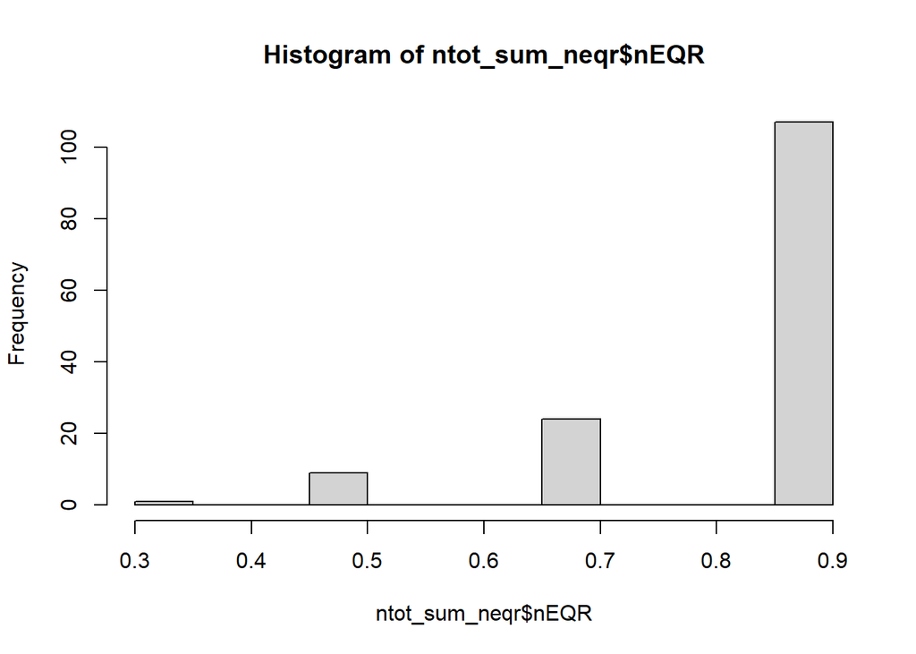

```r
# Distribution of nEQR values
hist(ntot_sum_neqr$nEQR)
```

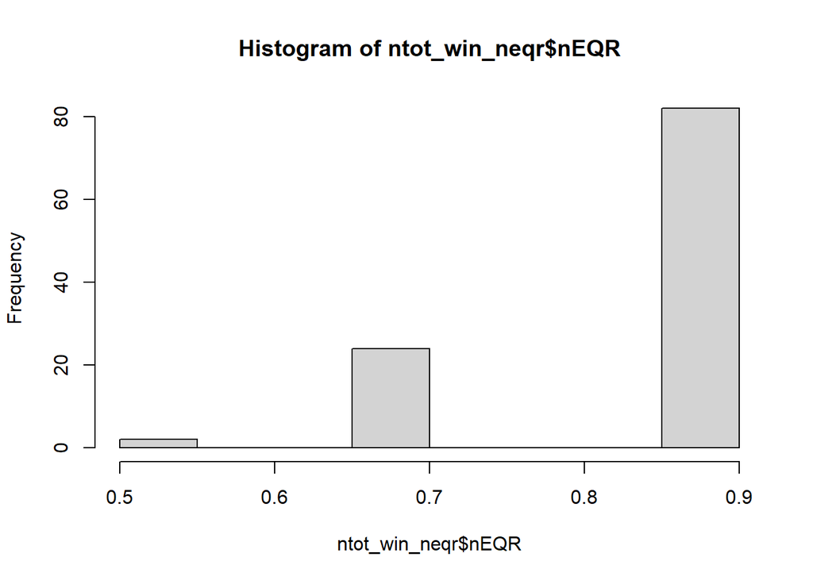

```r
hist(ntot_win_neqr$nEQR)
```

## 10. Results

The results by ecoregion for 2022-2024 are shown below.

```r
ntot_sum_neqr |>
  select(reg, nEQR) %>%
  group_by(reg) %>% summarize(`median nEQR`= median(nEQR))|>
  kable()
```

| reg | median nEQR |
| --- | --- |
| B | 0.9 |
| G | 0.9 |
| H | 0.9 |
| M | 0.9 |
| N | 0.9 |
| S | 0.7 |
| NA | NA |

```r
ntot_win_neqr |>
  select(reg, nEQR) %>%
  group_by(reg) %>% summarize(`median nEQR`= median(nEQR))|>
  kable()
```

| reg | median nEQR |
| --- | --- |
| B | 0.9 |
| G | 0.9 |
| H | 0.9 |
| M | 0.9 |
| N | 0.9 |
| S | 0.7 |
| NA | NA |

## 11. Export file

## 12. Author contributions

**CRediT statement**

**MeRIT attribution**

This part supplements the CRediT statement with more granularity for method section.

**TipSession Info**

This information is mainly aimed at developers that need to recreate the R environment that produced the html. Important note: this information is about the R session that was running when the html was rendered, and if some of the code chunks were not evaluated when the html was rendered, they may have been executed in a different environment.